# HW3

Caitlin Bolz

3/1/2021

# Introduction

Delays are unfortunately inevitable in life, but there are some steps an individual can take to reduce their airport flight delays. In this report I looked specifically at departure delay instead of arrival delay. I found departure delay to be more meaningful because it is based on what happens on the ground. An individual has more control over departure delay compared to arrival delay because arrival delay is based more on what happens while the plane is in the air.

First I looked at the relationship between time of day and mean delay. It was found that the earlier in the day you fly, the shorter your delays will be.

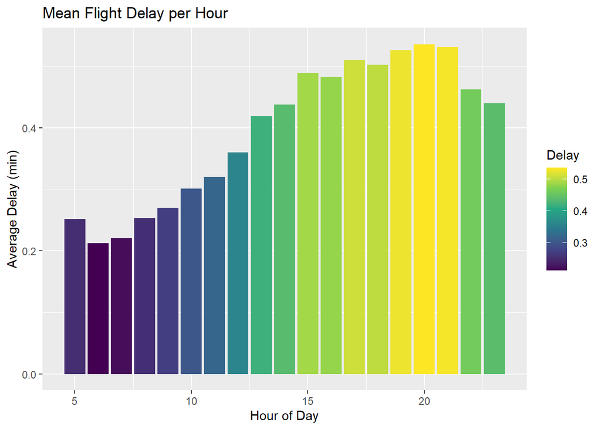

```r
flights %>%
  group_by(hour) %>%
  filter(!is.na(dep_delay)) %>%
  summarise(delay = mean( dep_delay > 0 , na.rm = T)) %>%
  ggplot() + geom_col(aes(hour, delay, fill = delay)) + scale_fill_continuous(type = "viridis") +
  labs(title = "Mean Flight Delay per Hour",
       x = "Hour of Day",
       y = "Average Delay (min)",
       fill = "Delay")
```

We also need to combine our flights and weather data sets for some of our analysis.

```r
flight_weather =
  flights %>%
  inner_join(weather, by = c(
    "origin" = "origin",
    "year" = "year",
    "month" = "month",
    "day" = "day",
    "hour" = "hour")) %>%
  mutate(delay = mean(dep_delay, na.rm = T))
```

# Destination

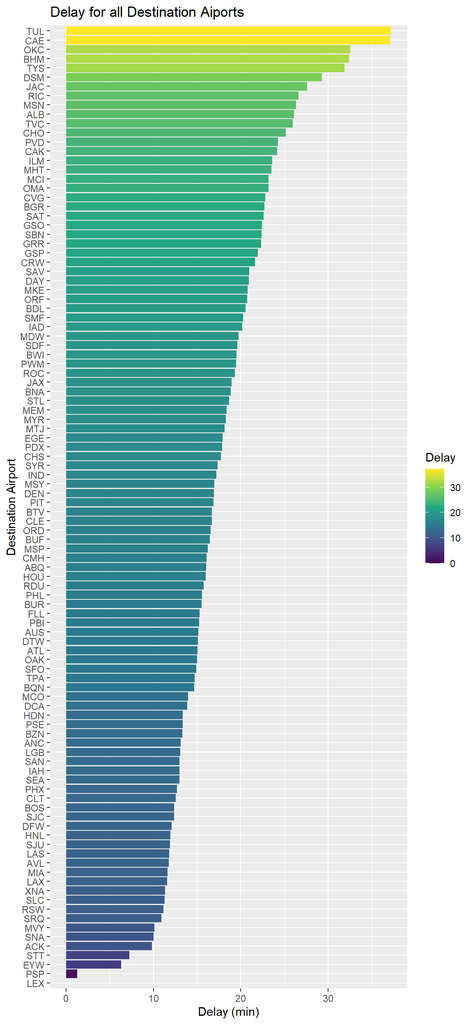

```r
flights %>%
  group_by(dest) %>%
  filter(!is.na(dep_delay)) %>%
  filter(!is.na(dest)) %>%
  summarise(tot_mins = sum(dep_delay[dep_delay > 0]),
            n = n(),
            avg = tot_mins/n) %>%
  ggplot() +
  geom_col(aes(avg, reorder(dest, avg), fill = avg)) +
  scale_fill_continuous(type = "viridis") +
  labs(title = "Delay for all Destination Aiports",
       x = "Delay (min)",
       y = "Destination Airport",
       fill = "Delay")
```

It isn’t likely that someone sees Tulsa has long delays and decides to avoid that city. So instead we need to look if there is a time of day that it is better to fly to these airports. When we take into account hour of day of the flight we see that generally there are shorter delays early in the day and longer delays later in the day. This doesn’t apply to every flight, but is a good rule of thumb to follow. If you have to fly to an airport that has long delay times, it is best to fly there earlier in the day.

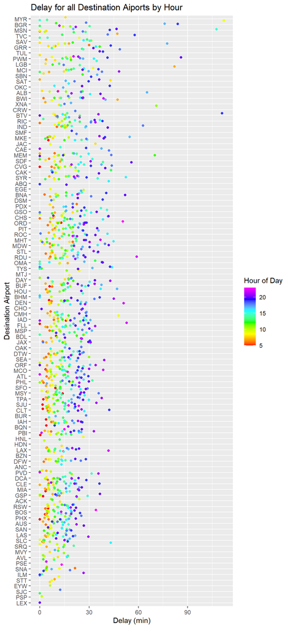

```r
flights %>%
  group_by(dest, hour) %>%
  filter(!is.na(dep_delay)) %>%
  filter(!is.na(dest)) %>%
  summarise(tot_mins = sum(dep_delay[dep_delay > 0]),
            n = n(),
            avg = tot_mins/n,
            .groups = "keep") %>%
  ggplot() +
  geom_jitter(aes(avg, reorder(dest, avg), col = hour)) +
  scale_color_gradientn(colours = rainbow(6)) +
  labs(title = "Delay for all Destination Aiports by Hour",
       x = "Delay (min)",
       y = "Desination Airport",
       col = "Hour of Day")
```

# Precipitation

It initially appears that the more precipitation on a given day, the longer your delays will be. The more we look into this, we realize that this isn’t necessarily true.

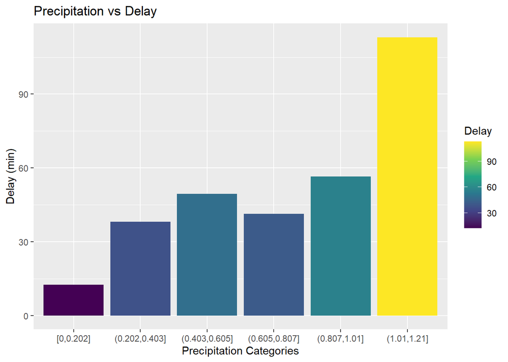

```r
flight_weather %>%
  ungroup() %>%
  mutate(precip_cat = cut_interval(precip, 6)) %>%
  group_by(precip_cat) %>%
  summarise(delay = mean(dep_delay, na.rm = T)) %>%
  ggplot(aes(x = precip_cat, y = delay, fill= delay)) +
  geom_col() + scale_fill_continuous(type = "viridis") +
  labs(title = "Precipitation vs Delay",
       x = "Precipitation Categories",
       y = "Delay (min)",
       fill = "Delay")
```

Looking at a graph of precipitation vs delay for each hour of the day it is hard to tell the relationship between the variables. It seems like there is a slightly positive relationship between precipitation and delay, but it is difficult to determine. As shown in previous graphs, we can see there is a relationship between hour of day and delay time. This relationship is fairly constant among precipitation amounts.

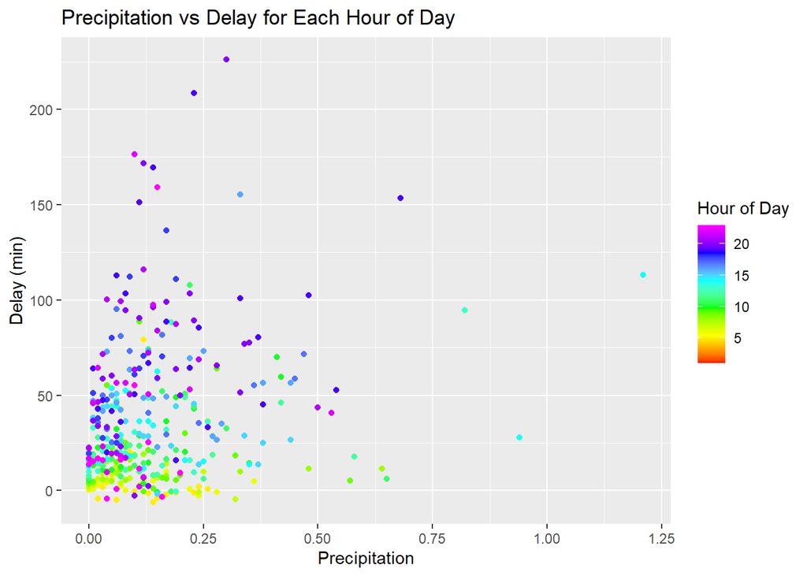

```r
flight_weather %>%
  ungroup() %>%
  group_by(hour, precip) %>%
  summarise(delay = mean(dep_delay, na.rm = T), .groups = "keep") %>%
  ggplot() +
  geom_point(aes(x =precip, y = delay, col = hour)) +
  scale_color_gradientn(colours = rainbow(6)) +
  labs(title = "Precipitation vs Delay for Each Hour of Day",
       x = "Precipitation",
       y = "Delay (min)",
       col = "Hour of Day")
```

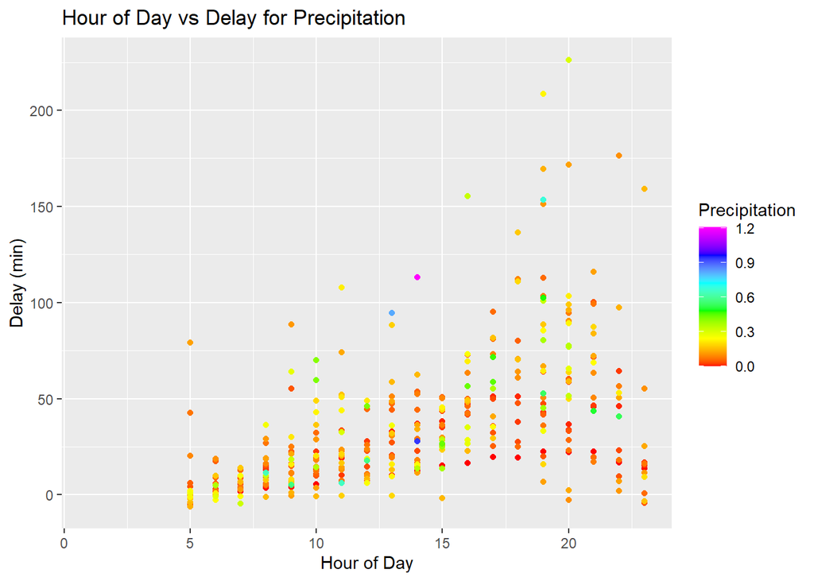

```r
flight_weather %>%
  ungroup() %>%
  group_by(hour, precip) %>%
  summarise(delay = mean(dep_delay, na.rm = T), .groups = "keep") %>%
  ggplot() +
  geom_point(aes(x =hour, y = delay, col = precip)) +
  scale_color_gradientn(colours = rainbow(6)) +
  labs(title = "Hour of Day vs Delay for Precipitation",
       x = "Hour of Day",
       y = "Delay (min)",
       col = "Precipitation")
```

# Visibility

The lower the visibility, the higher the delay on average.

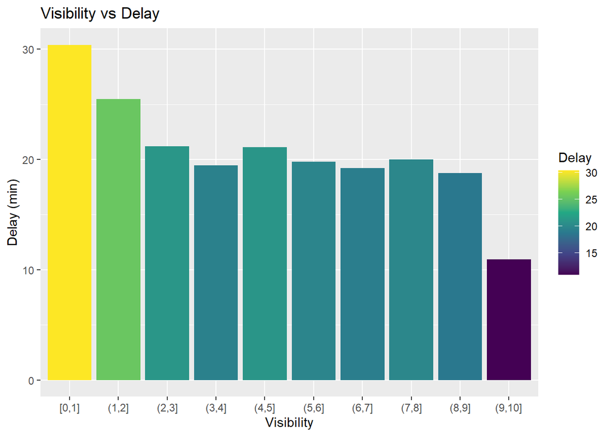

```r
flight_weather %>%
  ungroup() %>%
  mutate(visib_cat = cut_interval(visib, n = 10)) %>%
  group_by(visib_cat) %>%
  summarise(dep_delay = mean(dep_delay, na.rm = TRUE)) %>%
  ggplot(aes(x = visib_cat, y = dep_delay, fill = dep_delay)) +
  geom_col() + scale_fill_continuous(type = "viridis") +
  labs(title = "Visibility vs Delay",
       x = "Visibility",
       y = "Delay (min)",
       fill = "Delay")
```

This graph also shows us that as visibility decreases, delay times increase. When looking at the visibility for each mile grouping, the average delay time is lower if the flight is earlier in the day. You want your flight to have the highest visablity possible and leave earlier in the day to avoid delays.

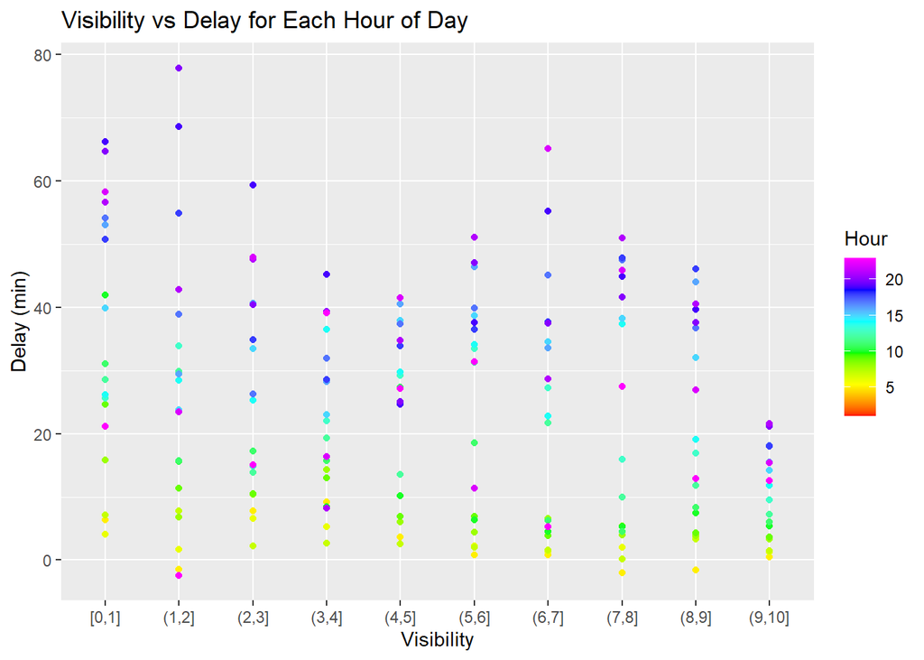

```r
flight_weather %>%
  ungroup() %>%
  mutate(visib_cat = cut_interval(visib, n = 10)) %>%
  group_by(hour, visib_cat) %>%
  summarise(dep_delay = mean(dep_delay, na.rm = TRUE), .groups = "keep") %>%
  ggplot() +
  geom_point(aes(x = visib_cat, y = dep_delay, col = hour)) +
  scale_color_gradientn(colours = rainbow(6)) +
  labs(title = "Visibility vs Delay for Each Hour of Day",
       x = "Visibility",
       y = "Delay (min)",
       col = "Hour")
```